# HW2: 出力

2024年10月05日 12:51

このhtmlを作成したソース・ファイルはhw2_rmarkdown0.rmdです

# 第1階層ヘッダ

## Second level header

markdownでは見出しを#を行頭に付けて作成します

```markdown
# 第1階層ヘッダ
## Second level header
```

リストは下記のようにして作成します

```markdown
* こうすればリストができます。
* リストは各行末に半角スペース2を入れて改行します。

1. 番号付きリストです。
1. 番号は自動で増えていきます。
1. 番号付きリストも各行末に半角スペース2を入れて改行します。
```

- こうすればリストができます。
- リストは各行末に半角スペース2を入れて改行します。
1. 番号付きリストです。
2. 番号は自動で増えていきます。
3. 番号付きリストも各行末に半角スペース2を入れて改行します。

### Third level header

```markdown
### Third level header
```

`tufte_html`では第3階層ヘッダは本文と変わらないので、通常は第2階層ヘッダまでしか使いません。

- [Edward Tufte](https://en.wikipedia.org/wiki/Edward_Tufte)は第2階層までしか使うべきでないと考えていたそうです。
- [Richard Feynmann](https://en.wikipedia.org/wiki/File:Richard_Feynman_Nobel.jpg)の講義資料で物理学のすべてが第2階層までで書かれていたことを根拠にしています。

# 表

````markdown
```{r}
tab <- cbind(letters[1:4], 1:4, LETTERS[1:4])
colnames(tab) <- c("alph", "num", "Alph")
tab
```
````

```
     alph num Alph
[1,] "a"  "1" "A"
[2,] "b"  "2" "B"
[3,] "c"  "3" "C"
[4,] "d"  "4" "D"
```

`kable`で表らしく出力

````markdown
```{r, eval = F}
knitr::kable(tab, caption = "An example table", align = rep("c", 3))
```
````

An example table

| alph | num | Alph |
| --- | --- | --- |
| a | 1 | A |
| b | 2 | B |
| c | 3 | C |
| d | 4 | D |

# 図

Rで乱数を発生させて 作業用のデータを作ります

`set.seed(123)`は乱数発生の初期値を123として設定しています。123と指定すれば、同じ乱数が発生し、同じ結果を見ることができます。`set.seed`で指定しないと、どのような初期値を使ったのか分からなくなります。`rnorm(1000)`は標準正規分布から1000個の値を発生させるコマンドです。

`cbind`コマンドで、データを1から500番目まで、501から1000番目を2列のデータとして整形しています。`"x"=`, `"y"=`とすることで、最初の列にx、2番目の列にはyという変数名を付けています。

````markdown
```{r generate data for figure}
set.seed(123)
x <- rnorm(1000)
x <- cbind("x"=x[1:500], "y"=1+2*x[1:500]+x[501:1000])
```
````

## Margin figure

マージンの図: 全体の傾向を見る目的であれば、マージン図が最適です

````markdown
```{r fig-margin, fig.margin=TRUE}
plot(x)
```
````

[output not shown]

## Main column figure

本文サイズの図: 細部を見せることも目的にあるならば、本文サイズの図を使います

````markdown
```{r, fig.cap='本文サイズ', out.width='100%'}
plot(x)
```
````

[output not shown]

## Full page figure

全幅サイズの図: これは少し大きすぎですが、どうしても必要な場合もあります

````markdown
```{r, fig.fullwidth=TRUE, fig.cap='Page width', out.width='100%'}
plot(x)
```
````

[output not shown]

## ggplot2

`ggplot2`パッケージを使うと視認性に優れた 描画ができます

`aes(x = x, y = y, fill = groups, color = groups, shape = groups)`ではx軸、y軸の変数を`x=x`、`y=y`と指定し、`fill`で塗り込む色、`color`で点の枠の色、`shape`で点の形を`groups`の値(ここではa, b, c, d)ごとに揃えるよう指定しています

以下では`data.table`パッケージもインストールして、データ作業をやりやすくしています

見やすい図

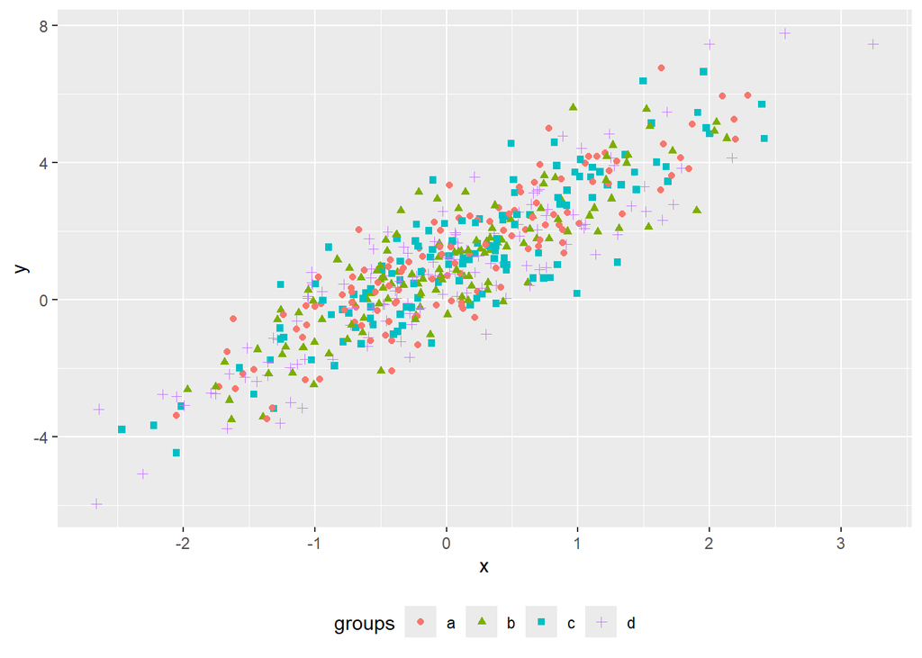

````markdown
```{r, fig.cap = "見やすい図"}
install.packages("data.table")
install.packages("ggplot2")
library(ggplot2)
x2 <- data.table(groups = rep(letters[1:4], 125), x)
ggplot(data = x2,
    aes(x = x, y = y, fill = groups, color = groups, shape = groups)) +
  geom_point(aes(colour = groups)) +
  scale_fill_viridis_d() +
  theme(legend.position = "bottom")
```
````